# El problema del coleccionista Panini

Una web app para estimar el número de paquetes que se deben comprar para llenar un album Panini

Rodrigo Gonzalez y Carlos A. Catania

18/09/2022

**Tiempo de lectura: 16 minute(s) @ 200 WPM.**

Cada 4 años, la locura comienza de nuevo: es hora de completar un nuevo álbum de Panini para la Copa Mundial de la FIFA. Este año no es una excepción y la empresa Panini ha lanzado un nuevo álbum con **638** figuritas para coleccionar con motivo de la Copa Mundial FIFA Qatar 2022. ¡Que comience la **Paninimanía**!

La colección Panini Qatar 2022 también incluye **20 figuritas extras** con 14 jugadores consagrados y 6 jugadores novatos. Estas figuritas sin numerar no forman parte del álbum principal. Las figuritas extras son muy difíciles de coleccionar: en promedio, se puede encontrar 1 figurita extra en 100 paquetes, según la información proporcionada en el sitio web de Panini.

Una antigua pregunta que se hace toda la humanidad es *¿cuántos paquetes tengo que comprar para completar el álbum Panini?*. En un esfuerzo por brindar algo de alivio a la población, hemos desarrollado una aplicación web en la que se puede estimar cuántos paquetes de Panini se tienen que comprar en función de la situación en particular: número de figuritas únicas que ya se tienen, número de amigos con quienes se está intercambiando figuritas y el precio de un paquete de Panini. Se puede probar esta [aplicación web aquí](https://model01.ingenieria.uncuyo.edu.ar/panini-app/).

El resto de este informe se dedicará a exponer lo que está detrás de esta aplicación web.

El [Problema del Coleccionista de Cupones](https://en.wikipedia.org/wiki/Coupon_collector%27s_problem) es un marco matemático para estimar cuántos cupones se deben coleccionar para ganar un premio de, por ejemplo, una promoción de cereal en caja. A primera vista, la teoría del Problema del Coleccionista de Cupones puede usarse para saber el número de paquetes que faltan para completar un álbum de Panini, pero no es exactamente el mismo problema. Al intentar completar un álbum de Panini, los coleccionistas deben reunir 638 figuritas al obtener 5 figuritas diferentes al azar al comprar 1 paquete. Panini garantiza que las figuritas dentro de un paquete no se duplican. Además, los coleccionistas de Panini pueden cooperar e intercambiar figuritas duplicadas. Esta es una práctica muy común. Debido a estas particularidades, este problema suele denominarse el **Problema del Coleccionista Panini** (PCP).

Entonces, se pueden abordar dos estrategias para completar el álbum Panini:

1. Coleccionar figuritas solo, sin intercambiar con otros coleccionistas.
2. Coleccionar figuritas y cooperar con otros coleccionistas para completar el álbum, un enfoque más común.

Evaluaremos estos dos escenarios para arrojar algo de luz sobre cuál es la mejor estrategia.

Además, queremos probar el impacto de 20 figuritas extras para completar la colección Panini, el álbum y figuritas adicionales.

Todo el código desarrollado para este informe se puede encontrar en [este enlace](https://github.com/rodralez/ds-portfolio).

## Estrategia sin intercambio

## Solución aproximada al problema del coleccionista Panini para la estrategia sin intercambio

El número de figuritas necesarias para completar un álbum Panini se puede estimar mediante la siguiente fórmula. Una muy buena explicación de dónde viene esta fórmula se puede encontrar en la ref. 1,

$$figuritas \approx n \cdot (ln(n) +
0.577)$$

donde *ln* es el logaritmo natural y *n* es el número de figuritas a coleccionar. En el caso del álbum Panini Qatar 2022, n es igual a 638. Entonces, el número de paquetes es,

$$paquetes \approx figuritas \div
5$$
La solución aproximada nos dice que en promedio se necesitan **898** paquetes para completar el álbum. Teniendo en cuenta que el precio de 1 paquete con 5 figuritas es de aproximadamente USD 1,25, como se indica en la ref. 3, se necesitan **USD 1.122** para completar el álbum.

### Aproximación por simulación para la estrategia sin intercambio

Aunque podemos usar la solución aproximada para estimar la cantidad de paquetes que se deben comprar, queremos probar otro enfoque para resolver este problema que será útil más adelante. A continuación, estimaremos la cantidad de paquetes necesarios en promedio para completar el álbum Panini generando 1000 simulaciones de Monte Carlo. Una simulación de Monte Carlo es una técnica matemática que se utiliza para estimar los posibles resultados de un evento incierto.

La figura 1 muestra la distribución estadística, o más formalmente la densidad de probabilidad, del número de paquetes necesarios para completar un álbum Panini sin intercambio. La distribución está sesgada a la derecha. Según 1000 simulaciones de Monte Carlo, en promedio se necesitan **899 paquetes** para completar el álbum, o **USD 1.124**. Este valor es bastante cercano al encontrado por la fórmula anterior. Considerando una probabilidad del 90%, lo que significa que es muy probable que necesite comprar N paquetes como máximo para completar el álbum, este número aumenta a **1.123 paquetes** o **USD 1.404** , una pequeña fortuna para el niño promedio.

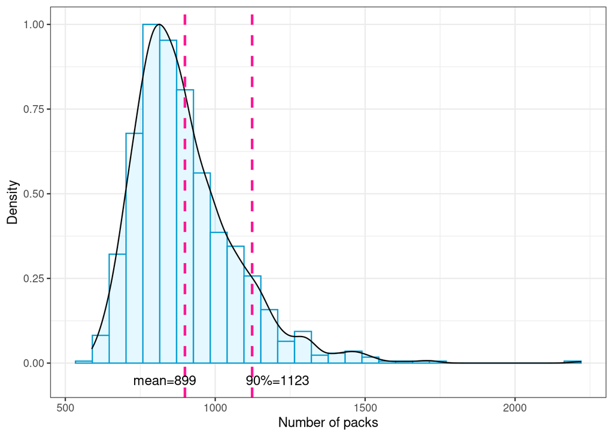

Fig. 1: Densidad de probabilidad del número de paquetes necesarios para completar un  
álbum Panini sin intercambio (1000 simulaciones).

## Estrategia con intercambio

### Aproximación por simulación para la estrategia con intercambio

Aunque se han propuesto algunas soluciones analíticas para el Problema del Coleccionista Panini con intercambio, estas fórmulas son muy difíciles de resolver para un gran número de figuritas y coleccionistas. Por lo tanto, nuestro enfoque para resolver el PCP con intercambio será mediante el uso de simulaciones de Monte Carlo.

Se asumen varios supuestos para las simulaciones de Monte Carlo para esta estrategia:

1. Todas las figuritas tienen la misma probabilidad de aparecer en un paquete (no hay escasez planificada de figuritas), o más formalmente, las figuritas se extraen de una distribución uniforme.
2. Todos los coleccionistas comienzan a coleccionar al mismo tiempo.
3. Todos los coleccionistas compran 1 paquete nuevo al mismo tiempo.
4. Después de comprar un nuevo paquete, los coleccionistas llenan sus álbumes. Las figuritas duplicadas van a la pila de intercambio de figuritas de cada coleccionista.
5. Luego, comienza una ronda de intercambio de figuritas. Aunque cada coleccionista puede intercambiar con cualquier otro coleccionista, el intercambio de figuritas es entre dos coleccionistas a la vez.
6. En cada ronda, los coleccionistas se ordenan al azar y buscan por turnos las figuritas faltantes en las pilas de intercambio de otros los coleccionistas, comenzando por el primer coleccionista en la cola.
7. Si dos coleccionistas pueden intercambiar figuritas, solo se puede intercambiar la cantidad mínima de figuritas. Por ejemplo, si el primer coleccionista en la cola puede ofrecer 2 figuritas y el segundo coleccionista en la cola puede ofrecer 3 figuritas, ambos coleccionistas solo pueden intercambiar 2 figuritas. Luego, el primer coleccionista en la cola sigue buscando las figuritas faltantes en la pila de intercambio del tercer coleccionista de la cola, y así sucesivamente.

La figura 2 muestra la densidad de probabilidad del número de paquetes necesarios para completar un álbum de Panini cuando se coopera con otros **10 coleccionistas**. La distribución vuelve a estar sesgada hacia la derecha. Pero la buena noticia es que, en este caso, se necesitan en promedio **321 paquetes** para completar el álbum, o **USD 401**, un tercio del dinero en comparación con la estrategia sin intercambio. Y considerando una probabilidad del 90%, este número se reduce a **442 paquetes** necesarios o **USD 552**. ¡Esto es **Panini-ntástico**!

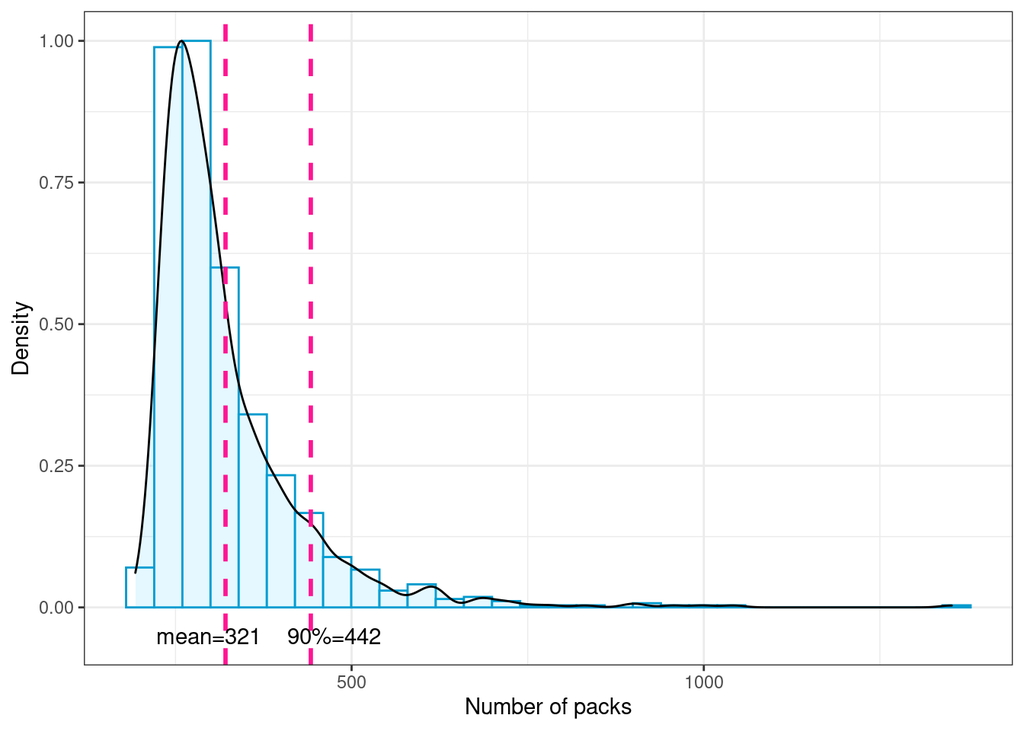

Fig. 2: Densidad de probabilidad del número de paquetes necesarios para completar un  
álbum Panini con intercambio (1000 simulaciones).

### Número de coleccionistas versus número de paquetes

Es interesante evaluar la relación que existe entre la cantidad de colaboradores que intercambian figuritas y la cantidad de paquetes que un coleccionista en particular tiene que comprar para completar el álbum de Panini.

La Figura 3 muestra esta relación para 1, 5, 10, 25 y 50 coleccionistas, donde 1 coleccionista es el mismo caso que para la estrategia sin intercambio. Se puede ver que la relación es asintótica, lo que significa que el intercambio con más coleccionistas es bueno, pero pasado un cierto punto casi no hay diferencia en intercambiar figuritas con más coleccionistas.

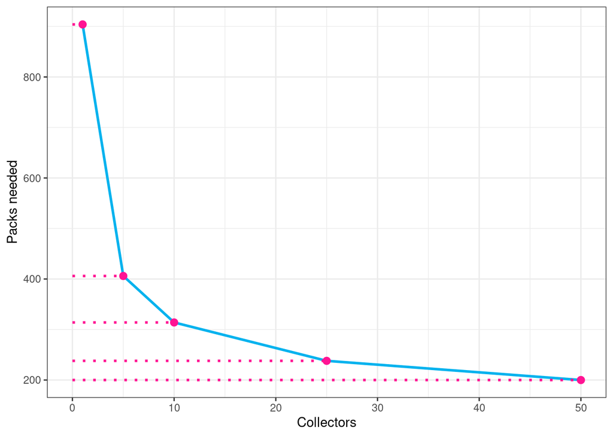

Fig. 3: Número de coleccionistas vs. paquetes necesarios para llenar un álbum Panini (1000 simulaciones).

## Figuritas extras

Todos hemos oído hablar de la *teoría conspirativa* de que cada álbum Panini tiene figuritas que son más difíciles de conseguir. Normalmente, estas figuritas están vinculadas a estrellas del fútbol como Lionel Messi o Cristiano Ronaldo. Esta escasez planeada de algunas figuritas por parte de Panini no ha sido probada hasta el momento. De hecho, en un artículo de Sardy y Velenik (ver ref. 4) se muestra que incluso si 10 amigos compran 100 paquetes cada uno y realizan un intercambio óptimo, a estos 10 coleccionistas les faltará una figurita poco más del 25% de el tiempo. ¡Y han comprado colectivamente 5000 figuritas!. Esto significa que algunas figuritas podrían percibirse como más escasas que otras.

Sin embargo, Panini ofrece 20 figuritas raras para coleccionar conocidas como **figuritas extras** (*extra stickers*). Panini informa en su sitio web que estas figuritas adicionales se insertan al azar, en promedio, cada 100 paquetes, por lo que verdaderamente son más difíciles de coleccionar. Aquí no hay gato encerrado. Estas figuritas no forman parte del álbum, por lo que se puede completar el álbum incluso sin conseguir una de estas raras figuritas coleccionables. De todos modos, queremos evaluar qué sucede con la cantidad de paquetes cuando el objetivo es completar el álbum Panini y coleccionar estas figuritas adicionales.

Para las simulaciones con figuritas extras consideramos que:

1. La colección total de figuritas comunes es de 638.
2. La colección total de figuritas extras es de 20.
3. La probabilidad de sacar 1 figurita común es $pc=1/638$.
4. La probabilidad de sacar 1 figurita extra es $px=pc/500$.

A continuación, repetiremos las simulaciones de Monte Carlo con figuritas extras solo para la estrategia sin intercambio, porque la mayoría de la gente no cambiará una figurita rara por una común, ¡ni siquiera por 200 figuritas comunes!.

### Aproximación por simulación para la estrategia sin intercambio con figuritas extras

La figura 4 muestra la densidad de probabilidad del número de paquetes necesarios para completar un álbum Panini con 20 figuritas extras sin intercambio. Podemos ver que la cantidad promedio de paquetes aumenta de 899 a una cantidad asombrosa de **227.260 paquetes** o **USD 284.075**, si se desean coleccionar figuritas extras. En otras palabras, se pueden coleccionar figuritas extras de Panini o comprar un Lamborghini. Una locura.

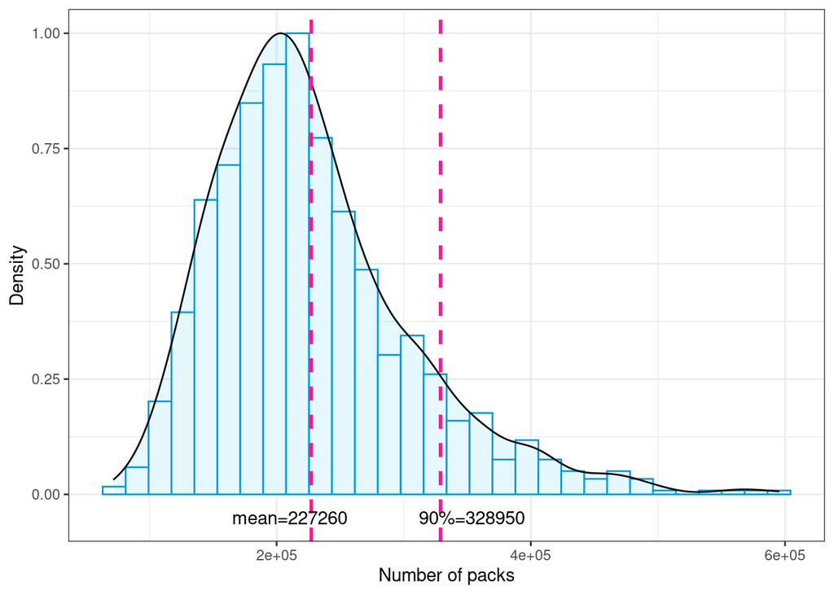

Fig. 4: Densidad de probabilidad del número de paquetes necesarios para completar un álbum Panini  
con 20 figuritas extras y sin intercambio (1000 simulaciones).

## Conclusiones

Claramente, la mejor estrategia para completar el álbum Panini Qatar 2022 es intercambiar figuritas con otros coleccionistas, cuantos más coleccionistas mejor hasta cierto punto. Incluso si intercambias figuritas solo con 4 personas, la cantidad de paquetes para completar el álbum se reduce a 400 (ver la Fig. 3), que es menos de la mitad de los paquetes necesarios en comparación con la colección individual. Finalmente, coleccionar figuritas extras es realmente difícil y tiene un fuerte impacto en la cantidad de paquetes que se deben comprar. Parece que un mejor enfoque es “hacer trampa” y comprar estas figuritas raras directamente en línea.

## Referencias

1. Andy Hayes and Geoff Pilling. Coupon Collector Problem. Accessed on September 2022, [link](https://brilliant.org/wiki/coupon-collector-problem/).
2. Delmarcelle, O., & Vrins, F. (2019). The Panini collector’s problem: optimal strategy and trading analysis (Doctoral dissertation, Master thesis), [pdf](https://dial.uclouvain.be/downloader/downloader.php?pid=thesis%3A20994&datastream=PDF_01).
3. Fortune Magazine. Inflation hits one of soccer fans’ favorite pastimes as filling the World Cup Panini sticker album will cost over $1,000, [link](https://fortune.com/2022/08/30/world-cup-soccer-inflation-panini-sticker-album-fifa/).
4. Sardy, S., & Velenik, Y. (2010). Paninimania: sticker rarity and cost-effective strategy. Swiss Statistical Society, 2-6, pdf.